# task6

Edgaras Petrauskas

Tuesday, April 05, 2016

## Forecasting: Principles & Practice

2. For each of the following series, make a graph of the data with forecasts using the most appropriate of the four benchmark methods: mean, naive, seasonal naive or drift. In each case, do you think the forecasts are reasonable? If not, how could they be improved?

**(a) Annual bituminous coal production (1920–1968). Data set bicoal.**

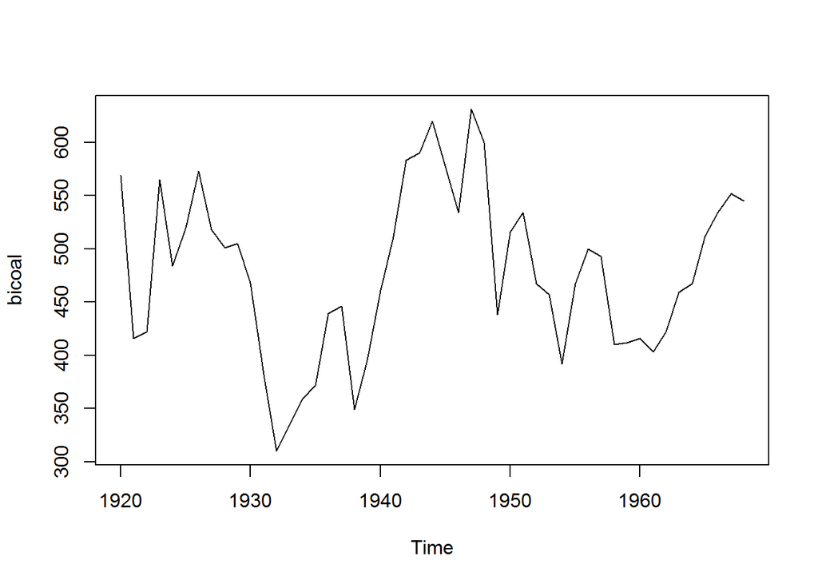

```r
library(fpp)
plot(bicoal)
```

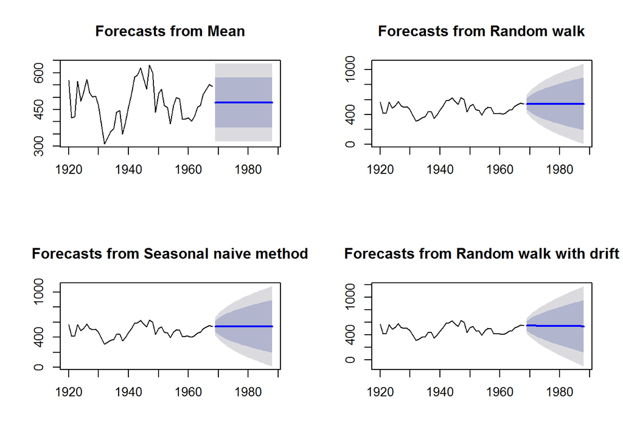

```r
par(mfrow = c(2,2))
plot(meanf(bicoal, h=20))
plot(rwf(bicoal, h=20))
plot(snaive(bicoal, h=20))
plot(rwf(bicoal, drift=TRUE, h=20))
```

Visi, išskyrus mean prognozę, atrodo priimtini.

**(b) Price of chicken (1924–1993). Data set chicken.**

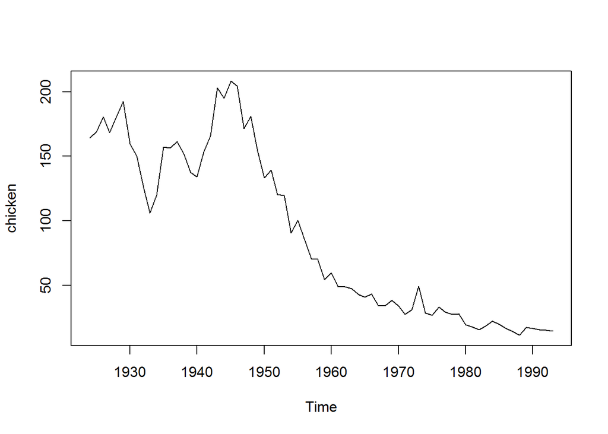

```r
plot(chicken)
```

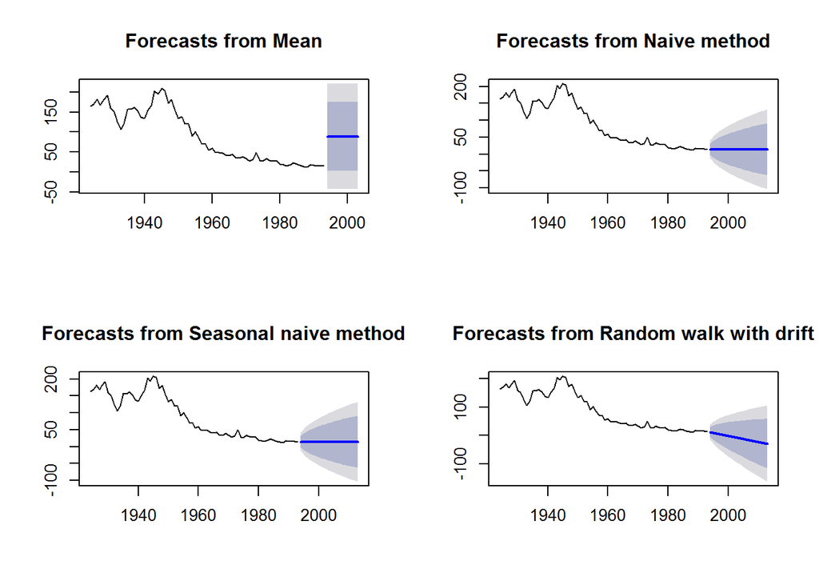

```r
par(mfrow = c(2,2))
plot(meanf(chicken, h=10))
plot(naive(chicken, h=20))
plot(snaive(chicken, h=20))
plot(rwf(chicken, drift=TRUE, h=20))
```

Antroji ir trečioji prognozės atrodo logiškiausiai (pirmoji akivaizdžiai netinka, ketvirtoji prognozuoja dar didesnį kritimą, nors atrodo, kad duomenys maždaug nusistovėjo).

**(c) Monthly total of people on unemployed benefits in Australia (January 1956–July 1992). Data set dole.**

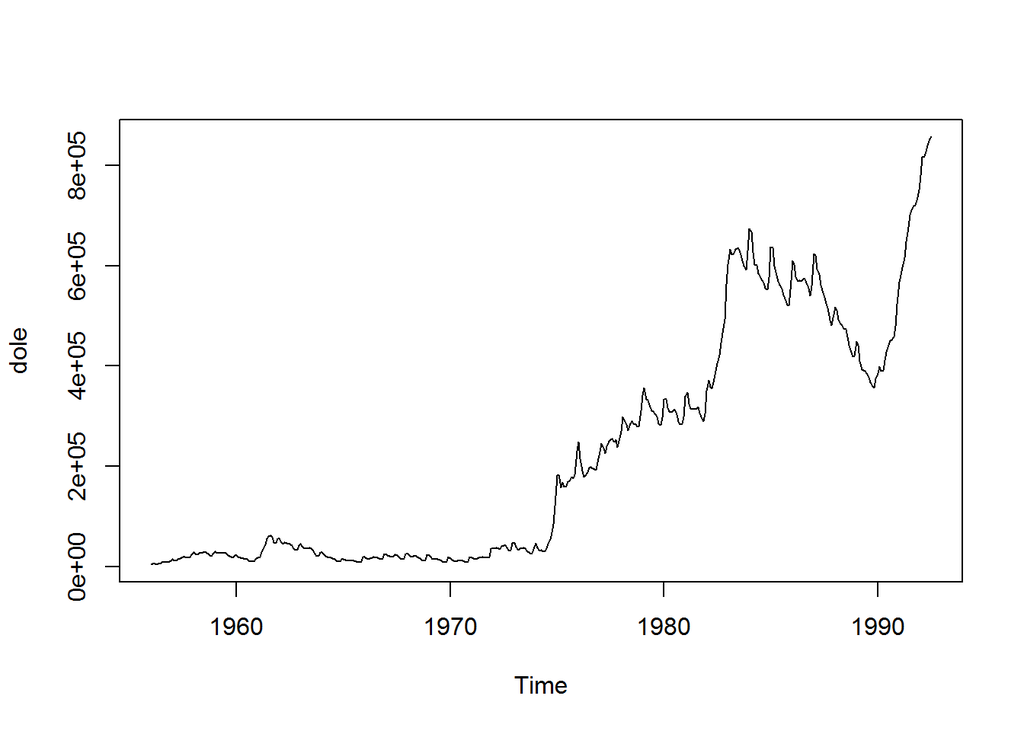

```r
plot(dole)
```

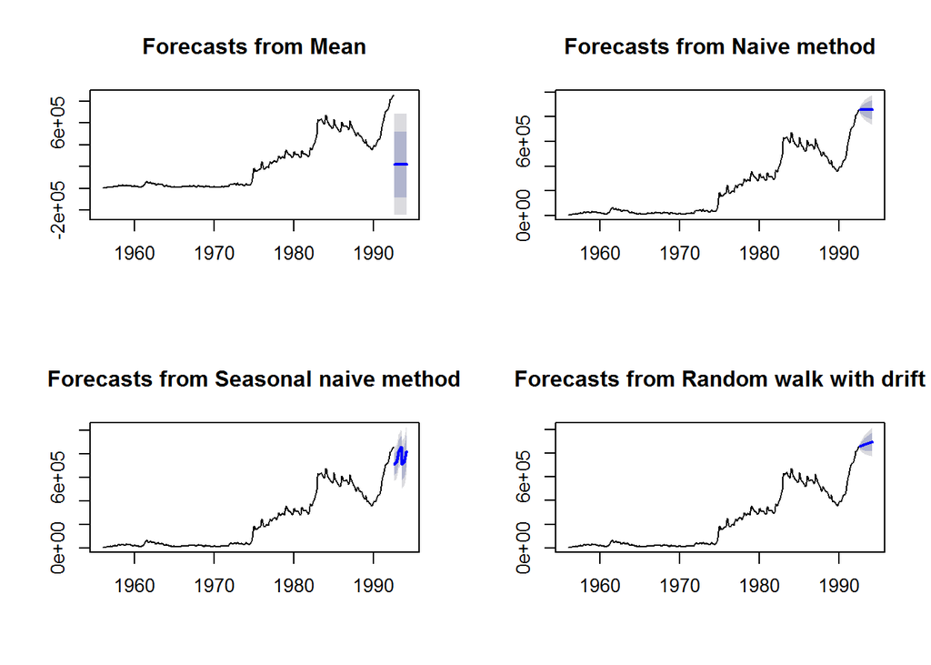

```r
par(mfrow = c(2,2))
plot(meanf(dole, h=20))
plot(naive(dole, h=20))
plot(snaive(dole, h=20))
plot(rwf(dole, drift=TRUE, h=20))
```

Vėlgi, akivaizdžiai netiksli pirmoji prognozė, o likusios atrodo logiškiau ir iš akies nustatyti geriausią nėra taip paprasta. Remiantis knygos 2.6 skyreliu, galima įvertinti prognozės gerumą paklaidų prasme.

|  | ME | RMSE | MAE | MPE | MAPE | MASE | ACF1 |
| --- | --- | --- | --- | --- | --- | --- | --- |
| Training set | 0 | 234952.4 | 207073.2 | -529.9107 | 569.7173 | 5.020758 | 0.9890219 |

|  | ME | RMSE | MAE | MPE | MAPE | MASE | ACF1 |
| --- | --- | --- | --- | --- | --- | --- | --- |
| Training set | 1944.664 | 13653.33 | 8220.185 | 0.5271669 | 7.301279 | 0.199309 | 0.4865014 |

|  | ME | RMSE | MAE | MPE | MAPE | MASE | ACF1 |
| --- | --- | --- | --- | --- | --- | --- | --- |
| Training set | 21826.9 | 73188.35 | 41243.41 | 4.481956 | 27.38484 | 1 | 0.9833331 |

|  | ME | RMSE | MAE | MPE | MAPE | MASE | ACF1 |
| --- | --- | --- | --- | --- | --- | --- | --- |
| Training set | 0 | 13514.13 | 8686.274 | -4.92872 | 9.750752 | 0.21061 | 0.4865014 |

Mažiausios paklaidos įvairiomis priemonėmis gaunasi 2 ir 4 prognozėse, todėl jas rinktis būtų logiškiausia.

**(d) Monthly total of accidental deaths in the United States (January 1973–December 1978). Data set usdeaths.**

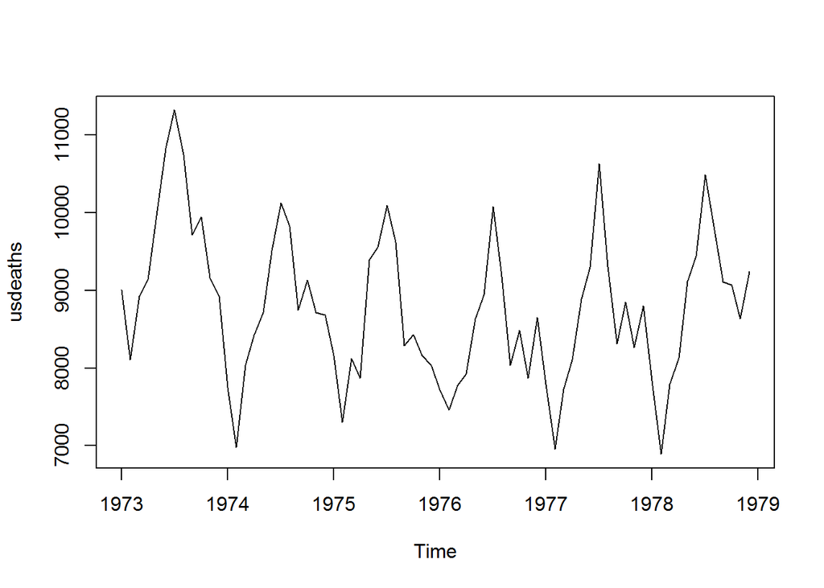

```r
plot(usdeaths)
```

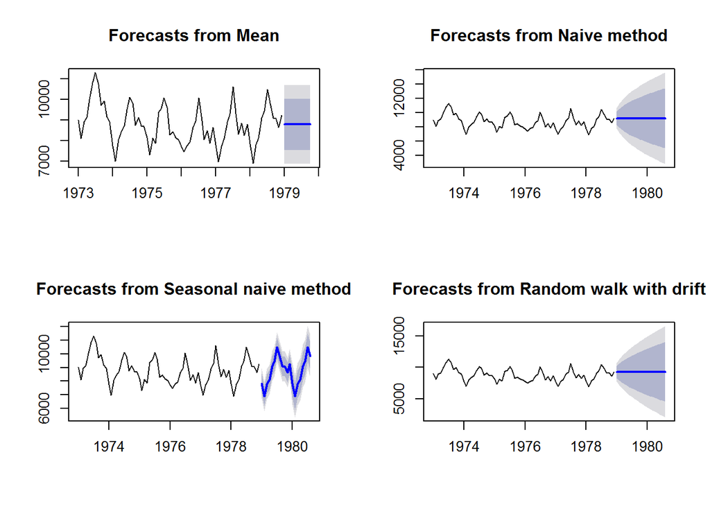

```r
par(mfrow = c(2,2))
plot(meanf(usdeaths, h=10))
plot(naive(usdeaths, h=20))
plot(snaive(usdeaths, h=20))
plot(rwf(usdeaths, drift=TRUE, h=20))
```

Akivaizdžiai geriausia trečioji prognozė, nes įvetina sezoniškumo įtaką.

**(e) Quarterly production of bricks (in millions of units) at Portland,Australia (March 1956–September 1994). Data set bricksq.**

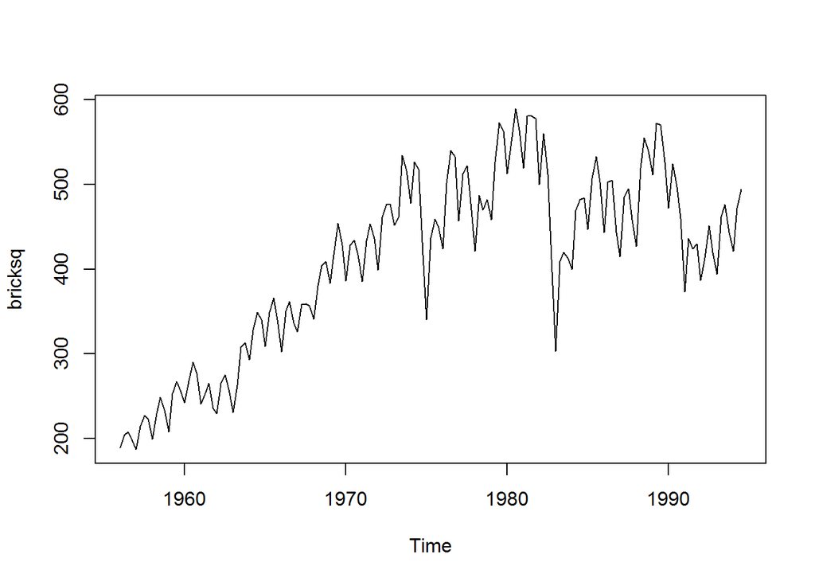

```r
plot(bricksq)
```

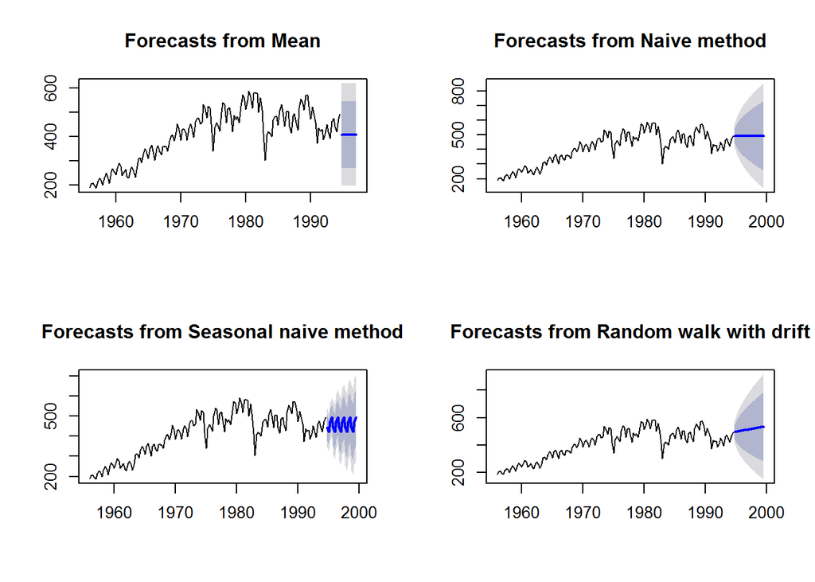

```r
par(mfrow = c(2,2))
plot(meanf(bricksq, h=10))
plot(naive(bricksq, h=20))
plot(snaive(bricksq, h=20))
plot(rwf(bricksq, drift=TRUE, h=20))
```

3 prognozėje labiau įvertinamas sezoniškumas, o 4 - trendas. Galima pasitikslinti prognozių tikslumą.

```r
kable(accuracy(snaive(bricksq, h=20)))
```

|  | ME | RMSE | MAE | MPE | MAPE | MASE | ACF1 |
| --- | --- | --- | --- | --- | --- | --- | --- |
| Training set | 6.834437 | 48.7093 | 35.60265 | 1.513132 | 8.678982 | 1 | 0.80655 |

```r
kable(accuracy(rwf(bricksq, drift=TRUE, h=20)))
```

|  | ME | RMSE | MAE | MPE | MAPE | MASE | ACF1 |
| --- | --- | --- | --- | --- | --- | --- | --- |
| Training set | 0 | 40.78204 | 32.92807 | -0.402607 | 8.199135 | 0.9248768 | -0.0785999 |

4 prognozė tikslesnė.

**(f) Annual Canadian lynx trappings (1821–1934). Data set lynx.**

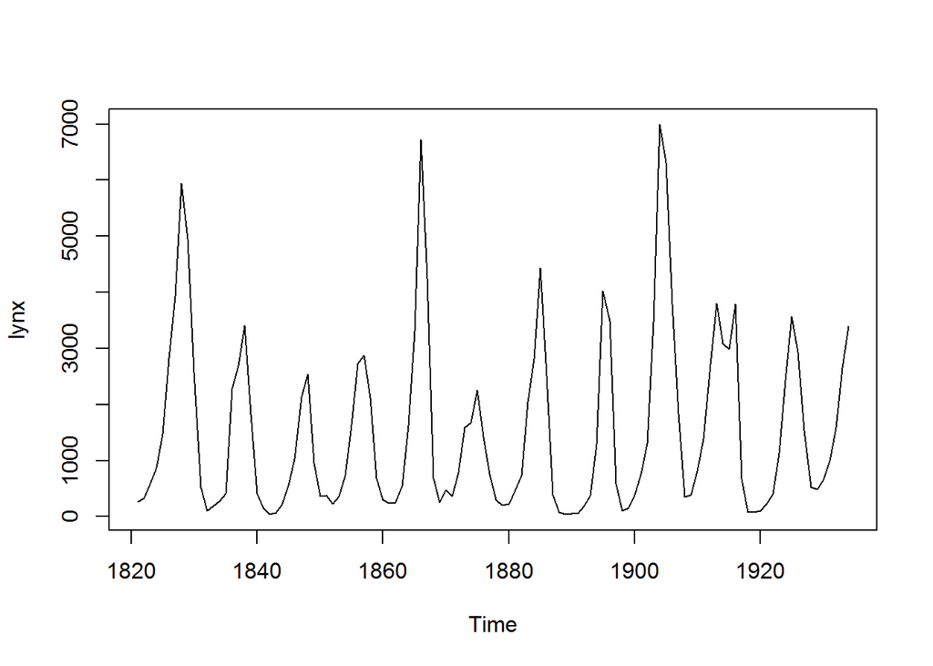

```r
plot(lynx)
```

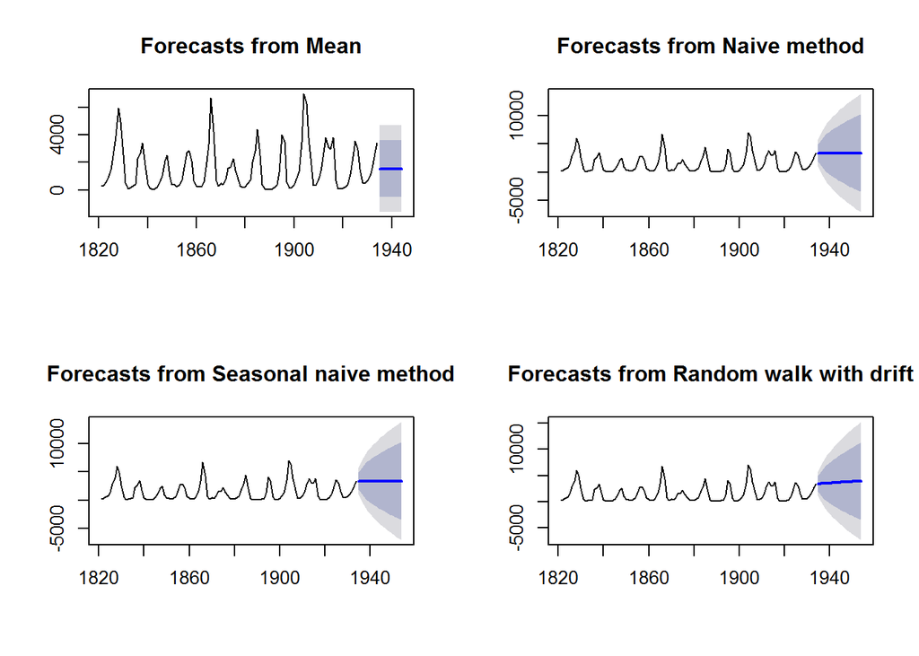

```r
par(mfrow = c(2,2))
plot(meanf(lynx, h=10))
plot(naive(lynx, h=20))
plot(snaive(lynx, h=20))
plot(rwf(lynx, drift=TRUE, h=20))
```

Reikėtų rinktis tarp 2 ir 3 prognozės, nes 4 yra didėjimo trendas, kurio tikrai nėra pradiniuose duomenyse ilguoju laikotarpiu. Tačiau gerai prognozei abiem atvejais trūksta periodiškumo.